# Characterizing Automobiles

Author

Nathan Butler

Published

March 17, 2025

# Setup

- Setup

```r
sh <- suppressPackageStartupMessages
sh(library(tidyverse))
sh(library(caret))
sh(library(fastDummies))
sh(library(class))
sh(library(ISLR)) # for the "Auto" dataframe
```

# Dataframe

- We use the `Auto` dataframe.

```r
data("Auto", package = "ISLR")
head(Auto)
```

```
  mpg cylinders displacement horsepower weight acceleration year origin
1  18         8          307        130   3504         12.0   70      1
2  15         8          350        165   3693         11.5   70      1
3  18         8          318        150   3436         11.0   70      1
4  16         8          304        150   3433         12.0   70      1
5  17         8          302        140   3449         10.5   70      1
6  15         8          429        198   4341         10.0   70      1
                       name
1 chevrolet chevelle malibu
2         buick skylark 320
3        plymouth satellite
4             amc rebel sst
5               ford torino
6          ford galaxie 500
```

- It has the following variable names, which describe various attributes of automobiles.

```r
names(Auto)
```

```
[1] "mpg"          "cylinders"    "displacement" "horsepower"   "weight"
[6] "acceleration" "year"         "origin"       "name"
```

# Multiple Regression

- Run a linear regression model with `mpg` as the dependent variable and `horsepower` and `year` as features (variables).
- Compute and comment on the RMSE.

```r
pacman::p_load(moderndive)
m1 <- lm(mpg ~ horsepower +year,Auto)
get_regression_summaries(m1)
```

```
# A tibble: 1 × 9
  r_squared adj_r_squared   mse  rmse sigma statistic p_value    df  nobs
      <dbl>         <dbl> <dbl> <dbl> <dbl>     <dbl>   <dbl> <dbl> <dbl>
1     0.685         0.684  19.1  4.37  4.39      424.       0     2   392
```

# Feature Engineering

- Create 10 features based on the `name` column.
- Remove all rows with a missing value.
- Ensure only `mpg` and the engineered features remain.
- Compute and comment on the RMSE.

```r
Auto$name<-as.character(Auto$name)
Auto_2 <- Auto %>%
  mutate(
    car_manufacturer = word(name, 1),
    name_length = nchar(name),
    sport = as.integer(str_detect(tolower(name), "sport")), #I used to really be into cars for like 6 months and so I just made lists of words I remember coming after car names
    luxury = as.integer(str_detect(tolower(name), "luxury")),
    gt = as.integer(str_detect(tolower(name), "gt")),
    custom = as.integer(str_detect(tolower(name), "custom")),
    special = as.integer(str_detect(tolower(name), "special")),
    deluxe = as.integer(str_detect(tolower(name), "deluxe")),
    has_number = as.integer(str_detect(name, "\\d")),
    super = as.integer(str_detect(tolower(name), "super"))) %>%
  select(mpg, car_manufacturer, name_length, sport,luxury, gt, custom, special,deluxe,has_number,super) %>%
  na.omit()
```

```r
m2 <- lm(mpg ~ .,Auto_2)
get_regression_summaries(m2)
```

```
# A tibble: 1 × 9
  r_squared adj_r_squared   mse  rmse sigma statistic p_value    df  nobs
      <dbl>         <dbl> <dbl> <dbl> <dbl>     <dbl>   <dbl> <dbl> <dbl>
1     0.442         0.371  33.9  5.82  6.19      6.24       0    44   392
```

> TODO: *The Root Mean Squared Error we got of roughly 5.82 means that, on average, our models predicted mpg differs from the actual mpg in the dataset by approximately 5.82 miles per gallon.*

# Classification

- Use either of $K$-NN or Naive Bayes to predict whether an automobile is a `chevrolet` or a `honda`.
- Explain your choice of technique.
- Report on your Kappa value.

```r
Auto_3 <- Auto_2 %>%
  mutate(chevy_honda = ifelse(car_manufacturer %in% c("chevrolet", "honda"), car_manufacturer, NA)) %>% #I couldnt quite tell if you wanted us to do just between chevrolet and Hondas or chevrolet or honda from all of the others. I did the first one.
  select(-car_manufacturer) %>%
  na.omit()

Auto_3$chevy_honda <- as.factor(Auto_3$chevy_honda)
```

```r
set.seed(505)
split <- createDataPartition(Auto_3$chevy_honda, p = 0.8, list = FALSE)
train <- Auto_3[split, ]
test <- Auto_3[-split, ]
fit <- train(chevy_honda ~ .,
             data = train,
             method = "knn",
             tuneLength = 15,
             metric = "Kappa",
             trControl = trainControl(method = "cv", number = 5))
confusionMatrix(predict(fit, test),factor(test$chevy_honda))$overall['Kappa']
```

```
    Kappa
0.6153846
```

```r
sort(table(Auto_3$chevy_honda))
```

```
    honda chevrolet
       13        43
```

# Binary Classification

- Predict whether a car is a `honda`.
- Use model weights.
- Display and comment on an ROC curve.

```r
Auto_4 <- Auto_2 %>% mutate(is_honda = as.integer(car_manufacturer == "honda")) %>% select(-car_manufacturer)

set.seed(505)
split <- createDataPartition(Auto_4$is_honda, p = 0.8, list = FALSE)
train <- Auto_4[split, ]
test <- Auto_4[-split, ]
```

```r
model <- glm(is_honda ~ ., data = train, family = binomial, weights = rep(1, nrow(train)))
```

```r
probabilities <- predict(model, test, type = "response")
```

```r
pacman::p_load(pROC)
roc_curve <- roc(test$is_honda, probabilities)
```

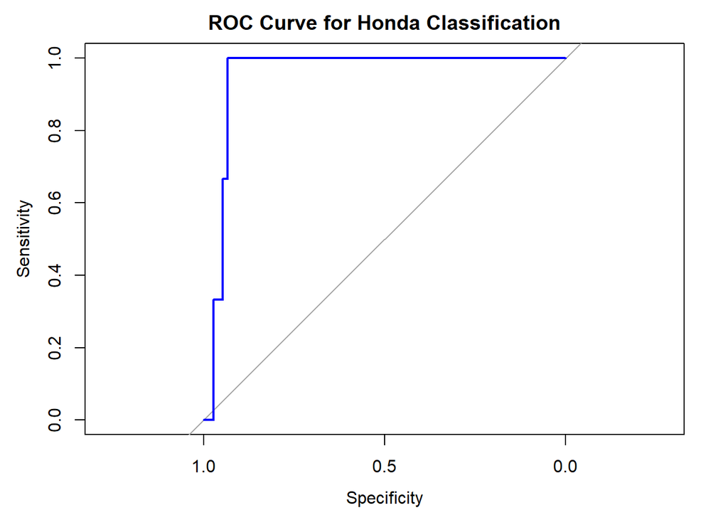

```r
plot(roc_curve, main="ROC Curve for Honda Classification", col="blue", lwd=2)
```

```r
auc_value <- auc(roc_curve)
auc_value
```

```
Area under the curve: 0.9511
```

# Ethics

- Based on your analysis, comment on the [Clean Air Act of 1970 and Ammendments of 1977](https://www.epa.gov/clean-air-act-overview/evolution-clean-air-act)
- Discuss the civic reposibilities of data scientists for:
  - Big Data and Human-Centered Computing
  - Democratic Institutions
  - Climate Change
- Provide at least one statistical measure for each, such as a RMSE, Kappa value, or ROC curve.

> TODO: Big Data and Human-Centered Computing *Data scientists must balance the potential benefits of large-scale data collection with concerns regarding privacy, bias, and fairness. The use of predictive analytics in areas such as healthcare, social services, and environmental monitoring should prioritize transparency and accountability. One important statistical measure in this context is the Kappa statistic, which helps evaluate the reliability of classification models in ensuring fair and unbiased predictions across diverse populations.*

```r
set.seed(505)
Auto_5 <- Auto %>%
  mutate(
    origin = as.factor(origin),
    horsepower = as.numeric(as.character(horsepower))) %>%
  select(-name) %>%  na.omit()
split <- createDataPartition(Auto_5$origin, p = 0.8, list = FALSE)
train <- Auto_5[split, ]
test <- Auto_5[-split, ]
fit <- train(origin ~ .,
             data = train,
             method = "knn",
             tuneLength = 15,
             metric = "Kappa",
             trControl = trainControl(method = "cv", number = 5))
confusionMatrix(predict(fit, test),factor(test$origin))$overall['Kappa']
```

```
    Kappa
0.4221388
```

> TODO: Democratic Institutions *Data science plays a crucial role in strengthening democratic institutions by promoting transparency, reducing misinformation, and improving electoral processes. Ethical considerations include mitigating algorithmic bias, and enhancing accessibility to civic resources. For instance, ROC curves are commonly used inclassification models to assess the trade off between true positive and false positive rate.*

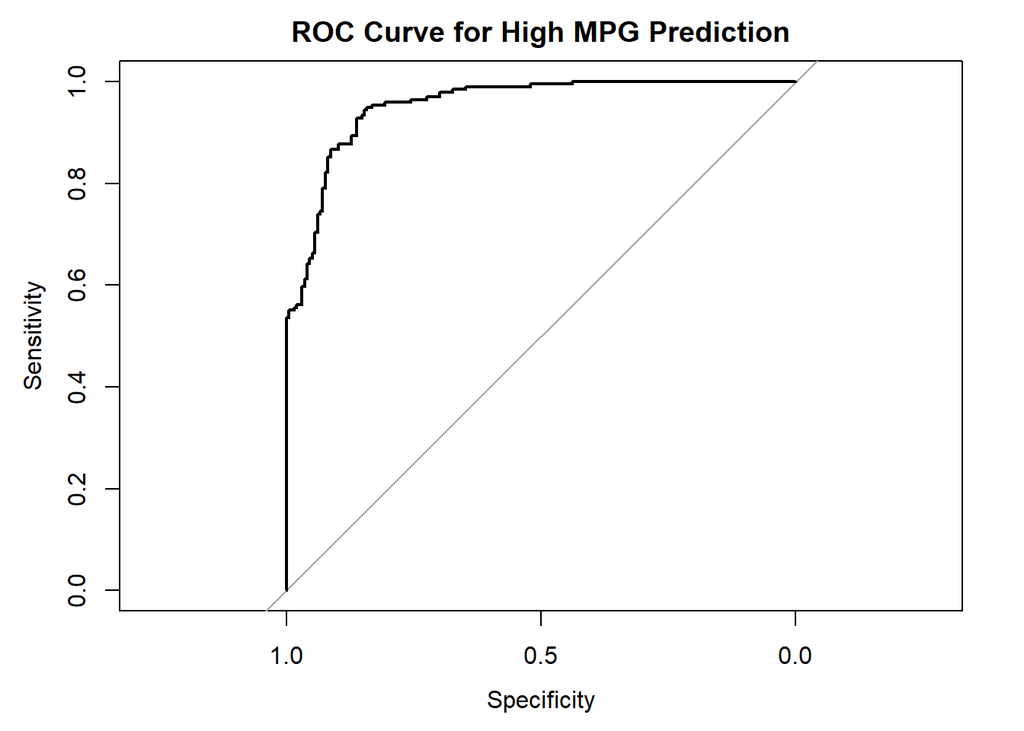

```r
Auto_5$high_mpg <- as.factor(ifelse(Auto_5$mpg > median(Auto_5$mpg), 1, 0))
model <- glm(high_mpg ~ horsepower + weight, data = Auto_5, family = binomial)
predictions <- predict(model, Auto_5, type = "response")

roc_curve <- roc(Auto_5$high_mpg, predictions)
plot(roc_curve, main = "ROC Curve for High MPG Prediction")
```

> TODO: Climate Change *In addressing climate change, data scientists must ensure that models used for climate predictions are both accurate and ethically applied. The use of remote sensing data, climate simulations, and statistical forecasting can help policymakers develop strategies to reduce carbon emissions and mitigate environmental risks. A commonly used metric in climate modeling is the Root Mean Squared Error which quantifies the accuracy of predictive models in forecasting temperature changes, sea level rise, and other environmental factors.*

```r
model <- lm(mpg ~ weight + horsepower, data = Auto_5)
predictions <- predict(model, Auto_5)

rmse <- sqrt(mean((Auto_5$mpg - predictions)^2))
rmse
```

```
[1] 4.223913
```